# Lecture 2: What Does an Economic Effect Mean?

Levels, marginal effects, elasticities, and functional form (Appendix A)

**Anchor question**  
Three models all relate infant mortality to national income. **Do they tell policymakers the same story about what happens when income rises—and would you trust the same model for poor and rich countries?**

**Textbook basis:** *Principles of Econometrics*, 5th ed., Appendix A, especially A.1.5–A.1.6, A.2–A.2.2, the introduction to A.3, selected derivative material in A.3.1, A.3.2, and Exercise A.2.

## Learning outcomes

After this lecture, students should be able to:

1. **Interpret** slope, marginal effect, and elasticity for linear and nonlinear economic relationships.
2. **Compare** alternative functional forms and explain how coefficient interpretation changes when variables are in levels or logarithms.
3. **Diagnose** a mathematically valid but economically misleading interpretation by checking domain, predictions, and the point of evaluation.

### What matters most

**Must understand**

- Slope is change in $y$ per unit change in $x$.
- Elasticity is percentage change in $y$ associated with a 1% change in $x$.
- Constant slope does **not** imply constant elasticity.
- A nonlinear marginal effect generally depends on where it is evaluated.
- Functional form is an economic assumption, not just a mathematical convenience.

**Useful reference material**

Derivative rules, the chain rule, Taylor approximation, derivatives of logarithms and exponentials, and second derivatives.

**You do not need to memorise**

The complete list of derivative rules, second-order optimisation conditions, integration rules, formal Taylor-series derivations, or multivariate maximum/minimum conditions.

# 0. Retrieval and connection

Suppose an economic outcome rises from 100 to 110 when $x$ rises from 20 to 25.

**Before calculating:** How could we describe the relationship between these changes in at least two different ways?

- Absolute change: $\Delta y=10$.
- Percentage change: $100(110-100)/100=10\%$.
- Slope over the change: $\Delta y/\Delta x=10/5=2$.

These are all correct, but they answer different questions.

**Today’s problem in miniature:** What exactly do we mean when we say that $x$ “affects” $y$?

# 1. The hook

Let $M$ denote infant mortality and $I$ annual per-capita income measured in thousands of dollars.

**Model 1 — Log-log**

$$\ln(M)=7.5-0.5\ln(I)$$

**Model 2 — Quadratic**

$$M=1400-100I+1.67I^2$$

**Model 3 — Linear**

$$M=1500-50I$$

## Commit to predictions

1. Which model has the **same marginal effect** of income everywhere?
2. Which model has the **same elasticity** everywhere?
3. If income rises from $3,000 to $4,000, will all three models predict approximately the same change in mortality?
4. Would you be willing to use one of these models across countries ranging from very poor to relatively rich?

Record answers before running code.

# 2. Minimal theory

## 2.1 Slope is a marginal effect

For a linear relationship

$$y=mx+b,$$

the slope is

$$m=\frac{\Delta y}{\Delta x},$$

and

$$\frac{dy}{dx}=m.$$

For Model 3,

$$\frac{dM}{dI}=-50.$$

**Economic translation:** a $1,000 increase in income is associated with 50 fewer units of the mortality measure.

## 2.2 A nonlinear relationship does not have one marginal effect

For Model 2,

$$\frac{dM}{dI}=-100+3.34I.$$

If someone asks, “What is the effect of income on mortality?”, what information is missing?

**Expected:** At what income level?

## 2.3 Elasticity asks a different question

$$\varepsilon_{MI}=\frac{dM}{dI}\frac{I}{M}.$$

Elasticity asks: **what percentage change in mortality corresponds to a 1% change in income?**

Therefore

$$\boxed{\text{constant slope} \neq \text{constant elasticity}}.$$

## 2.4 Logs can build elasticity directly into the model

For Model 1,

$$\ln(M)=7.5-0.5\ln(I),$$

so the elasticity is

$$\varepsilon_{MI}=-0.5.$$

A 1% increase in income is associated with approximately a 0.5% decrease in mortality.

But the **level marginal effect is not constant**.

# 3. Econometric lab

## Lab 1 — What do the three models actually look like?

**Question:** Do models that all describe a negative relationship between income and mortality necessarily tell the same economic story?

**Prediction:** Which two curves will diverge most as income rises?

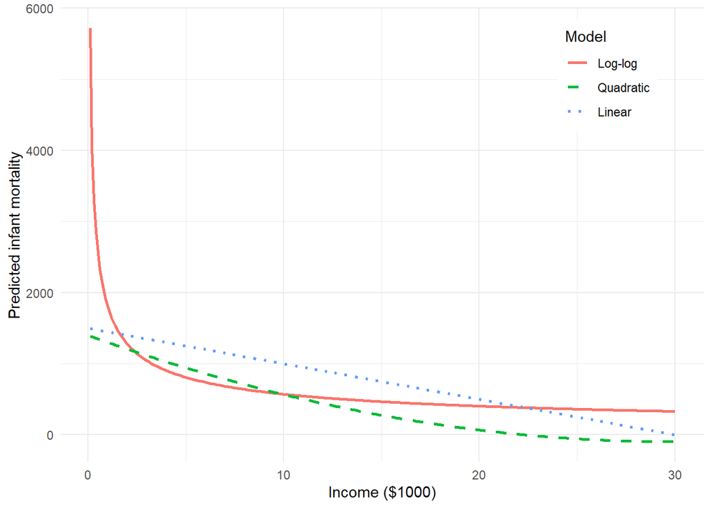

```r
# Load required libraries
library(ggplot2)
library(tidyr)

# 1. Define the model functions
m1 <- function(I) exp(7.5 - 0.5 * log(I))
m2 <- function(I) 1400 - 100 * I + 1.67 * I^2
m3 <- function(I) 1500 - 50 * I

# 2. Generate the sequence and build a wide data frame
income <- seq(0.1, 30, length.out = 300)

df <- data.frame(
  Income = income,
  `Log-log` = m1(income),
  Quadratic = m2(income),
  Linear = m3(income),
  check.names = FALSE # Keeps the exact names for the legend
)

# 3. Pivot the data to a "long" format for ggplot2
df_long <- pivot_longer(
  df,
  cols = -Income,
  names_to = "Model",
  values_to = "Mortality"
)

# Force the factor levels so the legend order matches your original plot
df_long$Model <- factor(df_long$Model, levels = c("Log-log", "Quadratic", "Linear"))

# 4. Create the plot
ggplot(df_long, aes(x = Income, y = Mortality, color = Model, linetype = Model)) +
  geom_line(linewidth = 1) + # 'linewidth' replaces 'size' in modern ggplot2
  scale_linetype_manual(values = c("solid", "dashed", "dotted")) + # Replicates lty = 1:3
  labs(
    x = "Income ($1000)",
    y = "Predicted infant mortality"
  ) +
  theme_minimal() +
  theme(
    legend.position = c(0.85, 0.85), # Moves the legend to the "topright"
    legend.background = element_rect(fill = "white", color = NA) # Makes legend text readable
  )
```

**Result:** the log model falls steeply initially and flattens; the linear model keeps falling at the same absolute rate; the quadratic bends toward a minimum and eventually becomes problematic.

**Decision:** A coefficient sign alone is not enough. Functional form determines how an effect changes across the range of $I$.

## Interactive model explorer

Move the slider before looking at the table. Ask students to predict which quantities will move and which will stay constant.

**Income, $I$ (thousand dollars):** 3.00

[output not shown]

## Lab 2 — Does “the effect of income” have one value?

**Question:** What is the marginal effect of another $1,000 of income at different income levels?

**Prediction:** Which model’s marginal effect will change most between $I=1$ and $I=25$?

```r
dm1 <- function(I) -0.5 * m1(I) / I
dm2 <- function(I) -100 + 3.34 * I
dm3 <- function(I) -50

I_test <- c(1, 3, 25)

data.frame(
  income = I_test,
  loglog = dm1(I_test),
  quadratic = dm2(I_test),
  linear = dm3(I_test)
)
```

```
  income     loglog quadratic linear
1      1 -904.02121    -96.66    -50
2      3 -173.97896    -89.98    -50
3     25   -7.23217    -16.50    -50
```

| Income | Log-log marginal effect | Quadratic | Linear |
| --- | --- | --- | --- |
| 1 | -904.021 | -96.660 | -50.000 |
| 3 | -173.979 | -89.980 | -50.000 |
| 25 | -7.232 | -16.500 | -50.000 |

**Decision:** Functional form embeds an assumption about how effects vary across the range of income.

## Lab 3 — Now ask the question in percentages

**Question:** Do the models look more similar when we compare elasticities rather than absolute marginal effects?

```r
e1 <- function(I) dm1(I) * I / m1(I)
e2 <- function(I) dm2(I) * I / m2(I)
e3 <- function(I) dm3(I) * I / m3(I)

data.frame(
  income = I_test,
  loglog = e1(I_test),
  quadratic = e2(I_test),
  linear = e3(I_test)
)
```

```
  income loglog   quadratic      linear
1      1   -0.5 -0.07425845 -0.03448276
2      3   -0.5 -0.24209214 -0.11111111
3     25   -0.5  7.33333333 -5.00000000
```

| Income | Log-log elasticity | Quadratic elasticity | Linear elasticity |
| --- | --- | --- | --- |
| 1 | -0.500 | -0.074 | -0.034 |
| 3 | -0.500 | -0.242 | -0.111 |
| 25 | -0.500 | **+7.333** | -5.000 |

**Pause:** What just happened at $I=25$ in the quadratic model?

## Lab 4 — Deliberate failure: trust the formula

A mechanical analysis might report:

> At $I=25$, the quadratic elasticity is $+7.33$, so higher income strongly increases infant mortality.

Should we accept that interpretation?

```r
data.frame(
  income = I_test,
  mortality_loglog = m1(I_test),
  mortality_quadratic = m2(I_test),
  mortality_linear = m3(I_test)
)
```

```
  income mortality_loglog mortality_quadratic mortality_linear
1      1        1808.0424             1301.67             1450
2      3        1043.8738             1115.03             1350
3     25         361.6085              -56.25              250
```

At $I=25$:

$$M_1=361.608,\qquad M_2=-56.25,\qquad M_3=250.$$

The quadratic model predicts **negative infant mortality**. Its derivative is still negative,

$$\frac{dM}{dI}=-16.5,$$

but because $M<0$,

$$\varepsilon=\frac{dM}{dI}\frac{I}{M}$$

becomes positive.

**The computer has made no mathematical error. The problem is the model.**  
A calculation can be mathematically correct and economically meaningless.

Find the first point where the quadratic predicts zero mortality:

```r
uniroot(m2, c(20, 25))$root
```

```
[1] 22.31861
```

$$I\approx22.319.$$

Above this value, the quadratic produces negative mortality until its second zero much later.

## Lab 5 — Domain matters too

The textbook exercise considers income over $0\leq I\leq30$. Can all three models actually be evaluated at zero?

```r
m1(0)
```

```
[1] Inf
```

R returns `Inf` because `log(0)` is `-Inf`; mathematically, the log-log specification requires

$$I>0.$$

Before interpreting a model, ask:

1. Is the calculation mathematically defined?
2. Is the prediction economically plausible?
3. Is the range supported by the data?

## Return to the anchor question

**Do the three models tell policymakers the same story?** No.

But do **not** jump to “therefore Model 1 is best.” We have not seen any observed data, residuals, uncertainty, model diagnostics, or identification strategy.

We can judge the models’ internal implications. We cannot yet establish empirical fit or causality.

# 4. AI Audit

## Prompt to give an LLM

> Three economists propose the following models relating infant mortality $M$ to annual per-capita income $I$, measured in thousands of dollars:

> $$\ln(M)=7.5-0.5\ln(I)$$

> $$M=1400-100I+1.67I^2$$

> $$M=1500-50I.$$

> Compare the economic meaning of the income effect in the three models. Calculate and interpret the marginal effect and elasticity at $I=1$, $I=3$, and $I=25$. Then recommend which model a policymaker should use to describe how raising national income would affect infant mortality over the range $0\leq I\leq30$. Explain your reasoning.

## Audit framework

Evaluate the AI answer rather than merely checking arithmetic.

1. **Coefficient vs. marginal effect vs. elasticity:** Did it distinguish them correctly?
2. **Domain:** Did it notice that the log-log model requires $I>0$?
3. **Predictions before interpretation:** Did it inspect the quadratic prediction at $I=25$ before interpreting $+7.33$?
4. **Association vs. causation:** Did it justify—or improperly assume—causal language?
5. **Model choice:** Did it claim one model is empirically “best” without observed data or diagnostics?
6. **Conclusion:** Does the recommendation actually follow from the evidence supplied?

### If the first AI answer is excellent

Use this follow-up:

> A policy adviser argues that the quadratic model shows that income increases infant mortality at high income levels because the elasticity at $I=25$ is $+7.33$. Construct the strongest possible argument supporting that interpretation, then construct the strongest rebuttal. Finally decide which argument is econometrically defensible and identify exactly which numerical result is misleading.

# 5. Exit problem

An analyst reports

$$\ln(Q)=4.2-0.8\ln(P).$$

She writes:

> “A one-unit increase in price reduces quantity by 0.8 units.”

**Is this interpretation correct? If not, correct it.**

**Expected answer**

No. The coefficient is an elasticity. A 1% increase in $P$ is associated with approximately a 0.8% decrease in $Q$.

**Important wrong answers reveal:**

- “Quantity falls by 0.8 units.” → every coefficient is being treated as a level slope.
- “Price rises by 0.8%.” → dependent and explanatory variables have been reversed.
- “A 1% price increase causes quantity to fall 0.8%.” → functional-form interpretation is right, but causality is unjustified.

# Assessment connection

## New setting: public transport demand

Suppose weekly bus journeys per 1,000 residents, $Q$, are related to the bus fare $P$ by three candidate models:

$$\text{A:}\quad Q=1200-40P$$

$$\text{B:}\quad \ln(Q)=8.0-0.6\ln(P)$$

$$\text{C:}\quad Q=1400-80P+2P^2.$$

## Part A — Closed-book / individual reasoning

### Question 1

Interpret the coefficient $-40$ in Model A.

**Solution**

A one-unit increase in the bus fare is associated with 40 fewer weekly journeys per 1,000 residents. It is a constant level marginal effect, not a constant elasticity.

### Question 2

Bus fares increase by approximately 10%. According to Model B, what percentage change in journeys would you predict?

**Solution**

Approximately $-0.6\times10\%=-6\%$.

### Question 3

For Model C,

$$\frac{dQ}{dP}=-80+4P.$$

Calculate the marginal effect at $P=10$ and $P=25$.

**Solution**

At $P=10$: $-40$. At $P=25$: $20$. The model eventually predicts that increasing fares increases bus use, which deserves strong economic scrutiny.

### Question 4

A student says:

> “Model B has the smallest coefficient in absolute value, so price has the weakest effect in Model B.”

Diagnose the error.

**Solution**

The coefficients have different units and meanings. $-40$ is a level marginal effect while $-0.6$ is an elasticity. Their numerical magnitudes cannot be compared directly.

## Part B — Open-book / AI allowed

> An AI argues that Model C should be preferred because the quadratic specification is more flexible than the linear and log-log models and can therefore fit more complicated economic behavior. Evaluate this recommendation. Explain what evidence you would need before choosing among Models A, B and C.

### Grading rubric

[output not shown]

# What comes next

Today we asked:

> **What does a mathematical relationship imply?**

Once regression begins, the questions become:

> **What relationship does the data support?**  
> **How uncertain is the estimate?**  
> **What can we legitimately infer from it?**

The conceptual sequence is:

$$\boxed{\text{Functional form}}
\rightarrow
\boxed{\text{Coefficient meaning}}
\rightarrow
\boxed{\text{Estimation}}
\rightarrow
\boxed{\text{Inference}}
\rightarrow
\boxed{\text{Economic conclusion}}.$$

# Instructor notes

**Open instructor-only notes**

### Likely misconceptions

- Every regression coefficient is “the effect”.
- Constant slope implies constant elasticity.
- Nonlinear automatically means better.
- If R returns a number, it must be interpretable.
- Positive elasticity must mean a positive marginal effect.
- Writing $M=f(I)$ establishes causation.

### Where discussion may run long

The $+7.33$ elasticity at $I=25$ can generate very productive discussion. Protect that discussion and shorten derivative algebra if necessary.

### If time is short

Skip the manual derivation of the log-log marginal effect, a separate marginal-effect plot, and the exact `uniroot()` calculation.

Do **not** skip the negative mortality prediction, the log-at-zero issue, or the distinction between marginal effect and elasticity.

### If the room is quiet

Ask:

- “Did R make a mistake when it gave us $+7.33$?”
- “Would you put $+7.33$ in a policy report?”
- “Can a coefficient be correctly calculated but meaningless?”

### Likely AI-generated answers

A strong LLM may calculate everything correctly and flag the negative prediction. The audit then shifts to whether it recommends a model without data, slides into causal language, distinguishes mathematical validity from economic plausibility, and notices the domain restriction at zero.

### Single most important idea

> **Never interpret a coefficient until you know the functional form, the units, the point of evaluation, and whether the resulting prediction makes economic sense.**